# Contenido sexual en redes sociales

Grupo A

2024-06-21

# Colaboradores

Marlon Barajas Acelas - 2202042  
Jose Gabriel Tomas Zapata - 2201779

# Introducción

En la era digital actual, el uso de las redes sociales ha revolucionado la manera en que las personas se comunican, interactúan y comparten información personal. Una de las manifestaciones más controvertidas de este fenómeno es la práctica de compartir contenidos sexuales explícitos o desnudos a través de plataformas en línea. Este comportamiento plantea importantes interrogantes sobre cómo las diferencias de género y las experiencias personales influyen en la disposición de individuos para participar en estas prácticas.

El presente proyecto de estadística tiene como objetivo investigar específicamente dos hipótesis principales relacionadas con el comportamiento de compartir desnudos en redes sociales.

# Objetivos

- Evaluar la diferencia de género en la disposición a compartir contenidos sexuales en redes sociales.
- Analizar la influencia de la experiencia sexual en el comportamiento de compartir desnudos.
- Validar estadísticamente las hipótesis.

# Metodología de la encuesta

El cuestionario se diseñaró de manera que todas las preguntas estén claramente formuladas y sean comprensibles para los encuestados. Las preguntas deben estar organizadas de manera lógica y secuencial, comenzando por información demográfica básica antes de abordar preguntas más sensibles.

Se seleccionará una muestra representativa de la población objetivo, que puede ser estudiantes universitarios de diferentes facultades. Es importante considerar la representación equitativa de género y grupos de edad dentro de la muestra para asegurar resultados más generalizables. Aplicación de la Encuesta:

La encuesta puede ser administrada de forma presencial o en línea, dependiendo de la accesibilidad y preferencias de los encuestados. Se debe asegurar la confidencialidad y anonimato de las respuestas para fomentar la sinceridad y reducir el sesgo. Recopilación de Datos:

Se recolectarán datos sobre variables como sexo, edad, facultad, redes sociales utilizadas y experiencias relacionadas con el envío y recepción de desnudos. Las respuestas a preguntas sensibles como las relacionadas con el grooming, prácticas sexuales, y comportamientos de envío de desnudos serán anónimas y tratadas con cuidado ético.

# Análisis de datos

## Tratamiento del dataset

```r
df <- read.csv('./contenido_sexual_en_redes_sociales.csv')
```

```r
df <- df[, !names(df) %in% 'Marca.temporal']
df <- df[, !names(df) %in% 'A.que.facultad.pertenece.']
```

```r
names(df) <- c('sex', 'age', 'social_networks', 'grooming_victim', 'sexual_experience', 'sent_nudes', 'sent_nudes_to_stranger', 'sent_nudes_without_request', 'starts_sending', 'view_once', 'allows_recording', 'shows_face', 'tries_not_to_be_identified', 'media_format', 'friends_share_nudes', 'asks_friends_share_nudes', 'shared_nudes', 'shares_nudes_frequently', 'sent_nudes_to_groups', 'sold_nudes', 'published_nudes', 'bought_nudes')
```

### División de las columnas de ‘social_networks’ y ‘media_format’

```r
redes_sociales <- c("Facebook", "Instagram", "Twitter", "Telegram", "Discord", "WhatsApp")

for (red_social in redes_sociales) {
  df[[tolower(red_social)]] <- ifelse(grepl(red_social, df$social_networks, ignore.case = TRUE), 1, 0)
}

df <- df[, !names(df) %in% "social_networks"]
```

```r
formatos <- c("Fotos", "Videos", "Shorts", "Gifs")

for (formato in formatos) {
  df[[tolower(formato)]] <- ifelse(grepl(formato, df$media_format,
ignore.case = TRUE), 1, 0)
}

df <- df[, !names(df) %in% "media_format"]
```

### Conversión de valores de texto a binarios (No=0 y Si=1)

```r
df[is.na(df)] <- 0
df[df == ''] <- 0

df$sex <- ifelse(df$sex == 'Hombre', 0, ifelse(df$sex == 'Mujer', 1, df$sex))
```

```r
df <- as.data.frame(lapply(df, function(x) {
  if (is.character(x)) {
    x <- ifelse(x == 'Si', 1, ifelse(x == 'No', 0, x))
  }
  return(x)
}))
```

Eliminando columnas con valores constantes

```r
df <- df[, !names(df) %in% 'shares_nudes_frequently']
df <- df[, !names(df) %in% 'sold_nudes']
df <- df[, !names(df) %in% 'published_nudes']
```

Ninguna de las personas encuestadas, comparte, vende o publica desnudos de otras personas.

## Exploración de resultados

### Medidas estadísticas básicas para el dataset

```r
summary.data.frame(df)
```

```
##       sex              age        grooming_victim  sexual_experience
##  Min.   :0.0000   Min.   :18.00   Min.   :0.0000   Min.   :0.0000
##  1st Qu.:0.0000   1st Qu.:18.00   1st Qu.:0.0000   1st Qu.:0.2500
##  Median :0.0000   Median :23.00   Median :0.0000   Median :1.0000
##  Mean   :0.3108   Mean   :22.15   Mean   :0.1081   Mean   :0.7432
##  3rd Qu.:1.0000   3rd Qu.:23.00   3rd Qu.:0.0000   3rd Qu.:1.0000
##  Max.   :1.0000   Max.   :35.00   Max.   :1.0000   Max.   :1.0000
##    sent_nudes     sent_nudes_to_stranger sent_nudes_without_request
##  Min.   :0.0000   Min.   :0.00000        Min.   :0.0000
##  1st Qu.:0.0000   1st Qu.:0.00000        1st Qu.:0.0000
##  Median :1.0000   Median :0.00000        Median :0.0000
##  Mean   :0.6216   Mean   :0.01351        Mean   :0.2838
##  3rd Qu.:1.0000   3rd Qu.:0.00000        3rd Qu.:1.0000
##  Max.   :1.0000   Max.   :1.00000        Max.   :1.0000
##  starts_sending     view_once      allows_recording   shows_face
##  Min.   :0.0000   Min.   :0.0000   Min.   :0.0000   Min.   :0.00000
##  1st Qu.:0.0000   1st Qu.:0.0000   1st Qu.:0.0000   1st Qu.:0.00000
##  Median :0.0000   Median :1.0000   Median :0.0000   Median :0.00000
##  Mean   :0.1351   Mean   :0.5135   Mean   :0.2297   Mean   :0.05405
##  3rd Qu.:0.0000   3rd Qu.:1.0000   3rd Qu.:0.0000   3rd Qu.:0.00000
##  Max.   :1.0000   Max.   :1.0000   Max.   :1.0000   Max.   :1.00000
##  tries_not_to_be_identified friends_share_nudes asks_friends_share_nudes
##  Min.   :0.0000             Min.   :0.0000      Min.   :0.00000
##  1st Qu.:0.0000             1st Qu.:0.0000      1st Qu.:0.00000
##  Median :0.0000             Median :0.0000      Median :0.00000
##  Mean   :0.3243             Mean   :0.2027      Mean   :0.04054
##  3rd Qu.:1.0000             3rd Qu.:0.0000      3rd Qu.:0.00000
##  Max.   :1.0000             Max.   :1.0000      Max.   :1.00000
##   shared_nudes    sent_nudes_to_groups  bought_nudes        facebook
##  Min.   :0.0000   Min.   :0.00000      Min.   :0.00000   Min.   :0.0000
##  1st Qu.:0.0000   1st Qu.:0.00000      1st Qu.:0.00000   1st Qu.:0.0000
##  Median :0.0000   Median :0.00000      Median :0.00000   Median :1.0000
##  Mean   :0.2027   Mean   :0.02703      Mean   :0.01351   Mean   :0.6622
##  3rd Qu.:0.0000   3rd Qu.:0.00000      3rd Qu.:0.00000   3rd Qu.:1.0000
##  Max.   :1.0000   Max.   :1.00000      Max.   :1.00000   Max.   :1.0000
##    instagram         twitter       telegram         discord
##  Min.   :0.0000   Min.   :0.0   Min.   :0.0000   Min.   :0.0000
##  1st Qu.:1.0000   1st Qu.:0.0   1st Qu.:0.0000   1st Qu.:0.0000
##  Median :1.0000   Median :0.5   Median :0.0000   Median :0.0000
##  Mean   :0.8514   Mean   :0.5   Mean   :0.2703   Mean   :0.3649
##  3rd Qu.:1.0000   3rd Qu.:1.0   3rd Qu.:1.0000   3rd Qu.:1.0000
##  Max.   :1.0000   Max.   :1.0   Max.   :1.0000   Max.   :1.0000
##     whatsapp          fotos            videos           shorts
##  Min.   :0.0000   Min.   :0.0000   Min.   :0.0000   Min.   :0.00000
##  1st Qu.:1.0000   1st Qu.:0.0000   1st Qu.:0.0000   1st Qu.:0.00000
##  Median :1.0000   Median :1.0000   Median :0.0000   Median :0.00000
##  Mean   :0.9865   Mean   :0.5811   Mean   :0.2838   Mean   :0.06757
##  3rd Qu.:1.0000   3rd Qu.:1.0000   3rd Qu.:1.0000   3rd Qu.:0.00000
##  Max.   :1.0000   Max.   :1.0000   Max.   :1.0000   Max.   :1.00000
##       gifs
##  Min.   :0.00000
##  1st Qu.:0.00000
##  Median :0.00000
##  Mean   :0.05405
##  3rd Qu.:0.00000
##  Max.   :1.00000
```

### Frecuencia de algunas respuestas

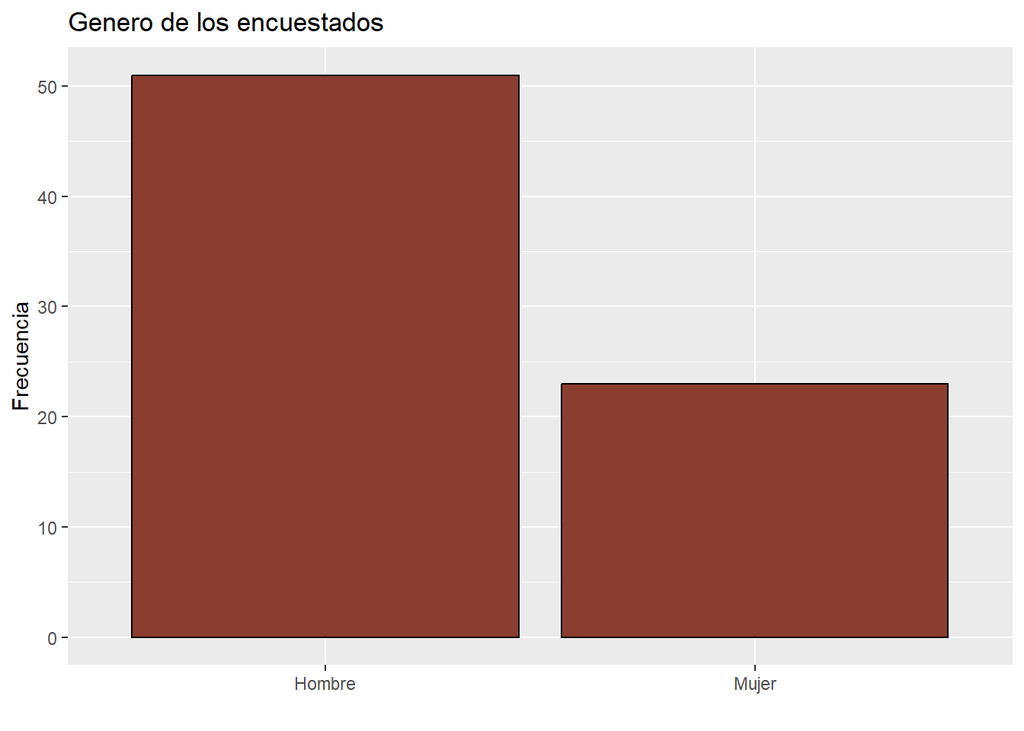

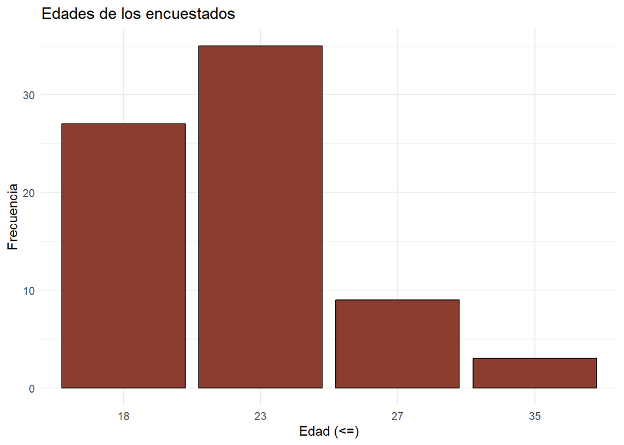

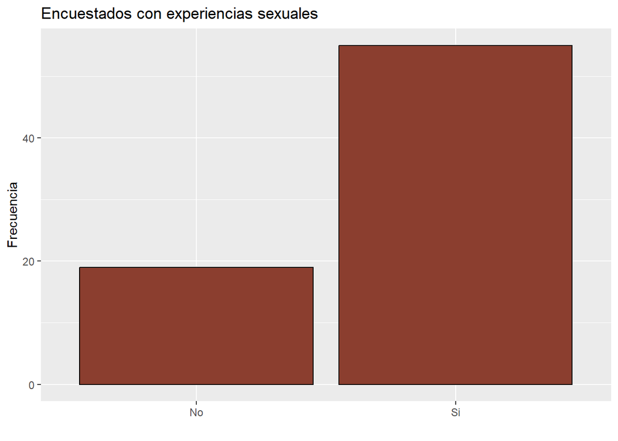

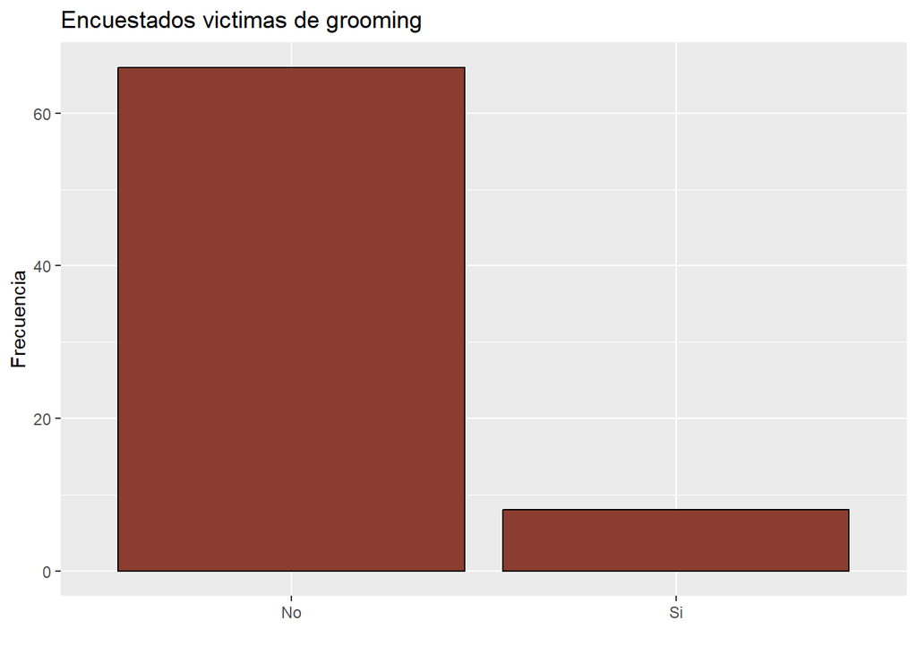

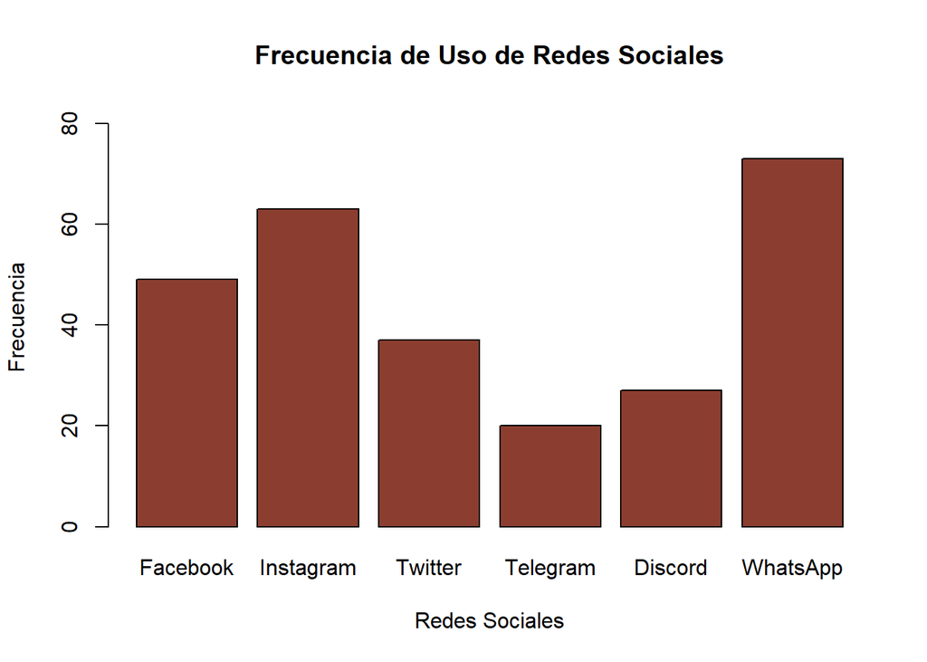

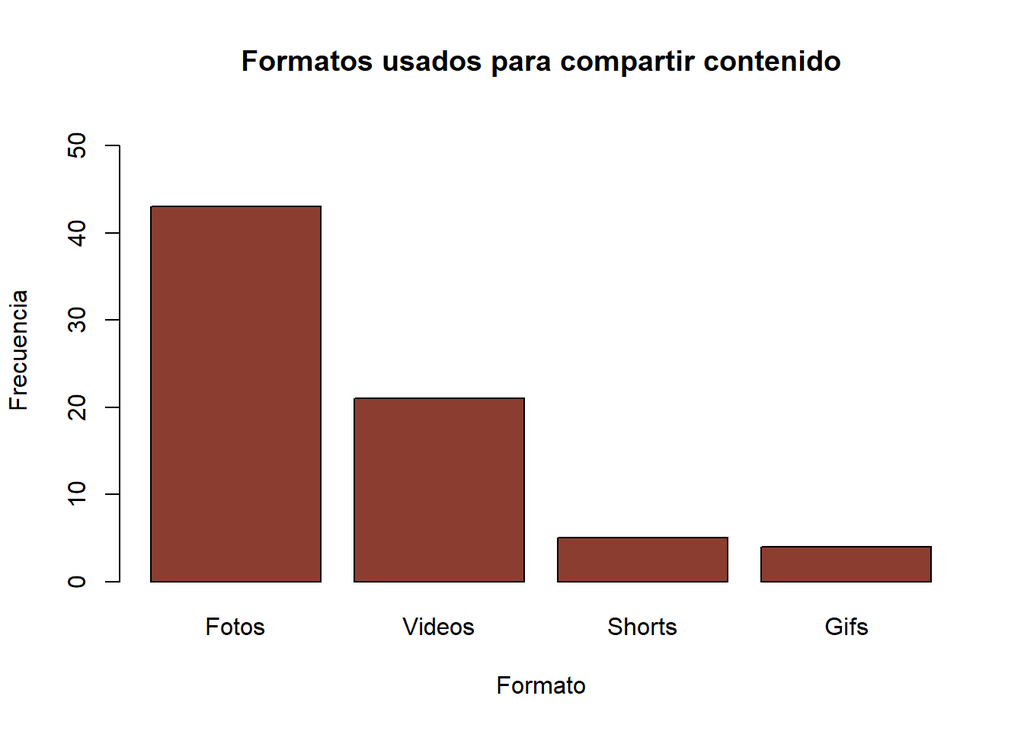

### Matriz de correlación para todas las variables

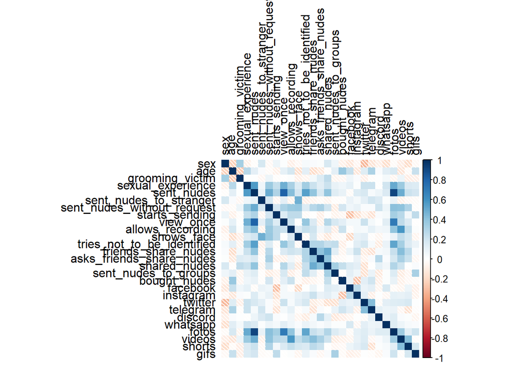

# Formulación de hipótesis

Basado en los resultados de las gráficas y las medidas estadísticas básicas para los datos generados, se plantearon las siguientes hipótesis:

1. El género puede determinar si una persona es más propensa a compartir contenído, específicamente los hombres.
2. Las personas que han tenido experiencias sexuales, tienden a compartir contenido con más facilidad.

# Pruebas estadísticas

## Primera hipótesis

Se plantea la hipótesis nula como la contraria a la planteada para tratar de rechazarla y así comprobar que el género influye en el envío de desnudos.

$H_0:$ El género no determina si una persona es más propensa a compartir contenído.

se genera una tabla con los valores necesarios para la prueba:

```r
tabla <- table(df$sex, df$sent_nudes)
print(tabla)
```

```
##
##      0  1
##   0 19 32
##   1  9 14
```

se calcularon las frecuencias esperadas:

```r
total_sex <- margin.table(tabla, 1)
total_sent_nudes <- margin.table(tabla, 2)
total_general <- sum(tabla)
frecuencias_esperadas <- outer(total_sex, total_sent_nudes) / total_general
print(frecuencias_esperadas)
```

```
##
##             0       1
##   0 19.297297 31.7027
##   1  8.702703 14.2973
```

se calculó consecuentemente el estadístico chi-cuadrado:

```r
chi_squared_stat <- sum((tabla - frecuencias_esperadas)^2 / frecuencias_esperadas)
print(chi_squared_stat)
```

```
## [1] 0.02370627
```

se obtuvo el valor crítico de la distribución chi_cuadrado:

```r
df <- (nrow(tabla) - 1) * (ncol(tabla) - 1)
alpha <- 0.05
critical_value <- qchisq(1 - alpha, df)
print(critical_value)
```

```
## [1] 3.841459
```

comparación del stadístico calculado con el valor crítico obtenido: